# 06_radians_from_unit_arc

## 06_radians_from_unit_arc

#### Question

1. The radian measure of an angle is the length of the arc on the [unit circle](https://en.wikipedia.org/wiki/Unit_circle) subtended by the angle. In mathematics, radians are the default way to measure an angle.

   Consider a circle with a radius of length $r=1$ meter. A [central angle](https://en.wikipedia.org/wiki/Central_angle), in [standard position](https://libraryguides.centennialcollege.ca/c.php?g=716824&p=5112868), subtends an arc of length $1.62$ meters.

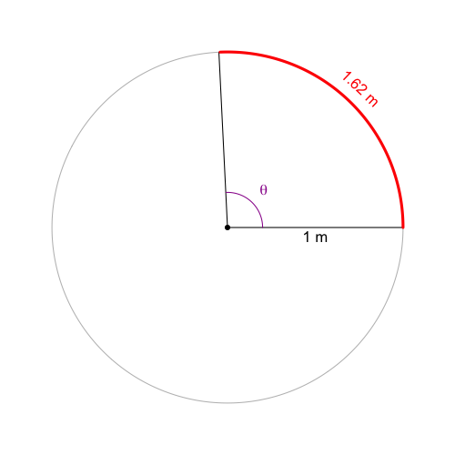

   The central angle, measured in degrees, is approximately equal to 93°. However, from the radius and the arc length, you should be able to calculate the angle in radians exactly.

   **Find $\theta$ in radians**.

#### Question

2. The radian measure of an angle is the length of the arc on the [unit circle](https://en.wikipedia.org/wiki/Unit_circle) subtended by the angle. In mathematics, radians are the default way to measure an angle.

   Consider a circle with a radius of length $r=1$ meter. A [central angle](https://en.wikipedia.org/wiki/Central_angle), in [standard position](https://libraryguides.centennialcollege.ca/c.php?g=716824&p=5112868), subtends an arc of length $1.95$ meters.

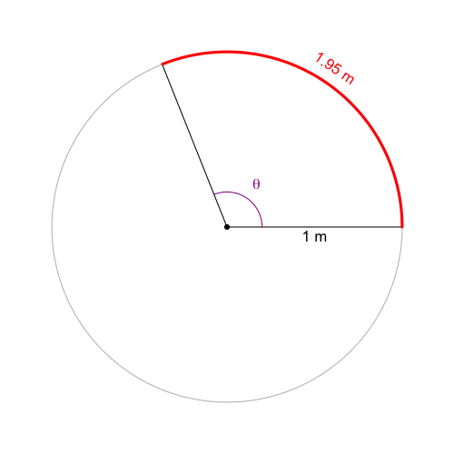

   The central angle, measured in degrees, is approximately equal to 112°. However, from the radius and the arc length, you should be able to calculate the angle in radians exactly.

   **Find $\theta$ in radians**.

#### Question

3. The radian measure of an angle is the length of the arc on the [unit circle](https://en.wikipedia.org/wiki/Unit_circle) subtended by the angle. In mathematics, radians are the default way to measure an angle.

   Consider a circle with a radius of length $r=1$ meter. A [central angle](https://en.wikipedia.org/wiki/Central_angle), in [standard position](https://libraryguides.centennialcollege.ca/c.php?g=716824&p=5112868), subtends an arc of length $2.59$ meters.

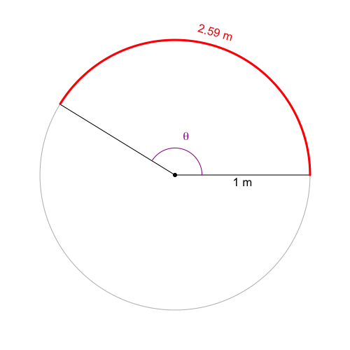

   The central angle, measured in degrees, is approximately equal to 148°. However, from the radius and the arc length, you should be able to calculate the angle in radians exactly.

   **Find $\theta$ in radians**.

#### Question

4. The radian measure of an angle is the length of the arc on the [unit circle](https://en.wikipedia.org/wiki/Unit_circle) subtended by the angle. In mathematics, radians are the default way to measure an angle.

   Consider a circle with a radius of length $r=1$ meter. A [central angle](https://en.wikipedia.org/wiki/Central_angle), in [standard position](https://libraryguides.centennialcollege.ca/c.php?g=716824&p=5112868), subtends an arc of length $3.64$ meters.

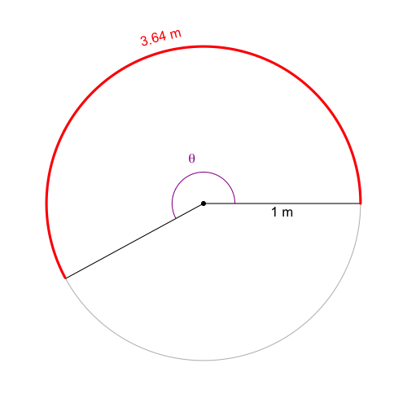

   The central angle, measured in degrees, is approximately equal to 209°. However, from the radius and the arc length, you should be able to calculate the angle in radians exactly.

   **Find $\theta$ in radians**.

#### Question

5. The radian measure of an angle is the length of the arc on the [unit circle](https://en.wikipedia.org/wiki/Unit_circle) subtended by the angle. In mathematics, radians are the default way to measure an angle.

   Consider a circle with a radius of length $r=1$ meter. A [central angle](https://en.wikipedia.org/wiki/Central_angle), in [standard position](https://libraryguides.centennialcollege.ca/c.php?g=716824&p=5112868), subtends an arc of length $1.42$ meters.

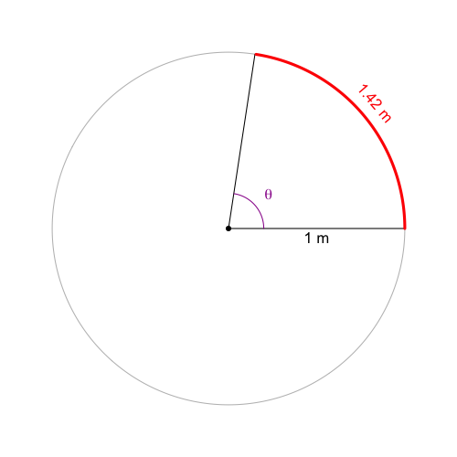

   The central angle, measured in degrees, is approximately equal to 81°. However, from the radius and the arc length, you should be able to calculate the angle in radians exactly.

   **Find $\theta$ in radians**.

#### Question

6. The radian measure of an angle is the length of the arc on the [unit circle](https://en.wikipedia.org/wiki/Unit_circle) subtended by the angle. In mathematics, radians are the default way to measure an angle.

   Consider a circle with a radius of length $r=1$ meter. A [central angle](https://en.wikipedia.org/wiki/Central_angle), in [standard position](https://libraryguides.centennialcollege.ca/c.php?g=716824&p=5112868), subtends an arc of length $3.61$ meters.

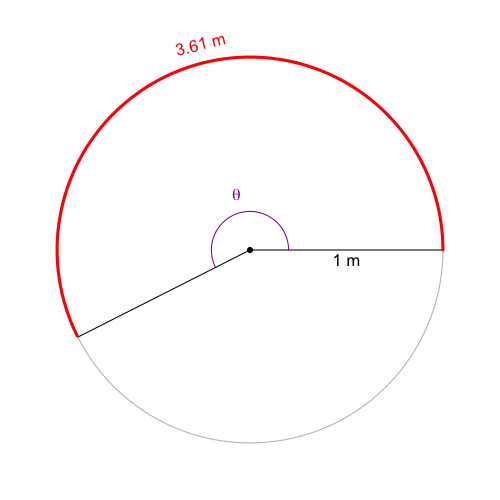

   The central angle, measured in degrees, is approximately equal to 207°. However, from the radius and the arc length, you should be able to calculate the angle in radians exactly.

   **Find $\theta$ in radians**.

#### Question

7. The radian measure of an angle is the length of the arc on the [unit circle](https://en.wikipedia.org/wiki/Unit_circle) subtended by the angle. In mathematics, radians are the default way to measure an angle.

   Consider a circle with a radius of length $r=1$ meter. A [central angle](https://en.wikipedia.org/wiki/Central_angle), in [standard position](https://libraryguides.centennialcollege.ca/c.php?g=716824&p=5112868), subtends an arc of length $3.75$ meters.

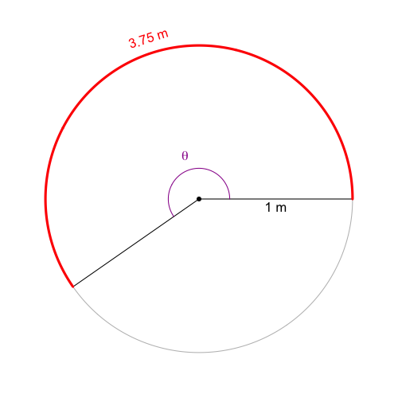

   The central angle, measured in degrees, is approximately equal to 215°. However, from the radius and the arc length, you should be able to calculate the angle in radians exactly.

   **Find $\theta$ in radians**.

#### Question

8. The radian measure of an angle is the length of the arc on the [unit circle](https://en.wikipedia.org/wiki/Unit_circle) subtended by the angle. In mathematics, radians are the default way to measure an angle.

   Consider a circle with a radius of length $r=1$ meter. A [central angle](https://en.wikipedia.org/wiki/Central_angle), in [standard position](https://libraryguides.centennialcollege.ca/c.php?g=716824&p=5112868), subtends an arc of length $2.86$ meters.

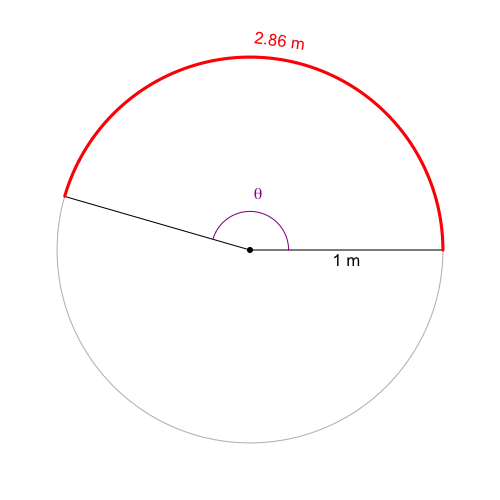

   The central angle, measured in degrees, is approximately equal to 164°. However, from the radius and the arc length, you should be able to calculate the angle in radians exactly.

   **Find $\theta$ in radians**.